# Lab session 2

Reka Solymosi

09/08/2017

# Learning outcomes:

- Univariate analysis
- Frequency
- Histograms
- Distributions
- Box plot
- Measures of central tendency
- Measures of variance

# Univariate analysis

You want to summarise your data. So let’s think about this.

Grab the crime data from Blackboard. Save it into your workin directory, and open it up with excel.

It should open up like this, with your **variable** names as column headers:

[figure not shown]

Under the column headers you have your 420228 rows, one for each of the 420228 crimes in your data. Recall that these are your **observarions**. Also, that therefore your **unit of analysis** in this data at this moment is each individual crime.

Anyway let’s say we want to talk about your variables. Like let’s say that you want to talk about the variable crime type. What level of measurement does this variable have? Is it a category? (hint: yes) Does it have a meaningful order? (hint: no). So it’s a nominal variable.

Okay so we want to find out about this variable. We know it’s a categorical variable, so if you’ve done your reading you will now know that you want to be looking at a frequency table to describe it. A **frequency table** will tell you the number of times that each value that the variable can take appears in your data. In other words, the frequency! Since each row is a crime incident, every time a particular value appears in your data, it means that a crime that belongs to that crime category occurred.

Here’s an example of a frequency table. Let’s say we have this data set of waiters and waitresses who work at Lil’ Bits restaurant. Here is our data in table format:

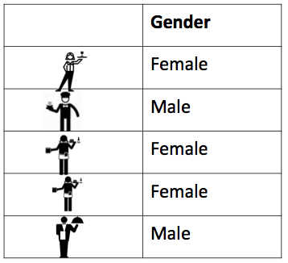

[figure not shown]

I hope that illustrates the concept. However in real life you are unlikely to want to manually count each occurrence of each value the variable can take in your data. Definitely would not be a fun activity with the 420228 rows in your GMP crimes data. Luckily excel makes this much easier for us.

## Creating a frequency table in Excel

# Measures of central tendency